# Hypothesis testing: demonstration

POLI 210 — Seminar 11

Author

Brad LeVeck

Published

November 18, 2026

# Start here

Open this file in RStudio. Run the setup first, then the sections in order. To reproduce everything from scratch, restart R and **Run All** or **Render**. All data below are simulated teaching examples; no downloads are required. The household example illustrates a design feature of Gerber, Green, and Larimer (2008), **not a replication of their results**.

```r
library(ggplot2)
library(dplyr)
theme_set(theme_minimal(base_size = 14))
blue <- "#006D9C"
orange <- "#BA4A27"
B <- 4000
```

# 1. A null model we can count

Eight cups: four milk-first, four tea-first. The taster selects exactly four as milk-first. Let $K$ be the number of actual milk-first cups in that selection. Under random guessing, every set of four is equally likely.

$$P_0(K=k)=\frac{\binom{4}{k}\binom{4}{4-k}}{\binom{8}{4}}.$$

```r
tea <- data.frame(k = 0:4)
tea$prob <- choose(4, tea$k) * choose(4, 4 - tea$k) / choose(8, 4)
tea
```

```
  k       prob
1 0 0.01428571
2 1 0.22857143
3 2 0.51428571
4 3 0.22857143
5 4 0.01428571
```

```r
sum(tea$prob)
```

```
[1] 1
```

```r
p_tea <- sum(tea$prob[tea$k >= 4])
p_tea
```

```
[1] 0.01428571
```

This is an **upper-tail** test: successful discrimination gives large $K$. With perfect performance, $p=1/70$. If $K=3$, the tail includes both 3 and 4, so $p=17/70$, not merely $P_0(K=3)$.

```r
set.seed(21101)
cups <- c(rep("milk-first", 4), rep("tea-first", 4))
k_sim <- replicate(10000, {
  selected <- sample(cups, size = 4, replace = FALSE)
  sum(selected == "milk-first")
})
mean(k_sim >= 4)
```

```
[1] 0.0137
```

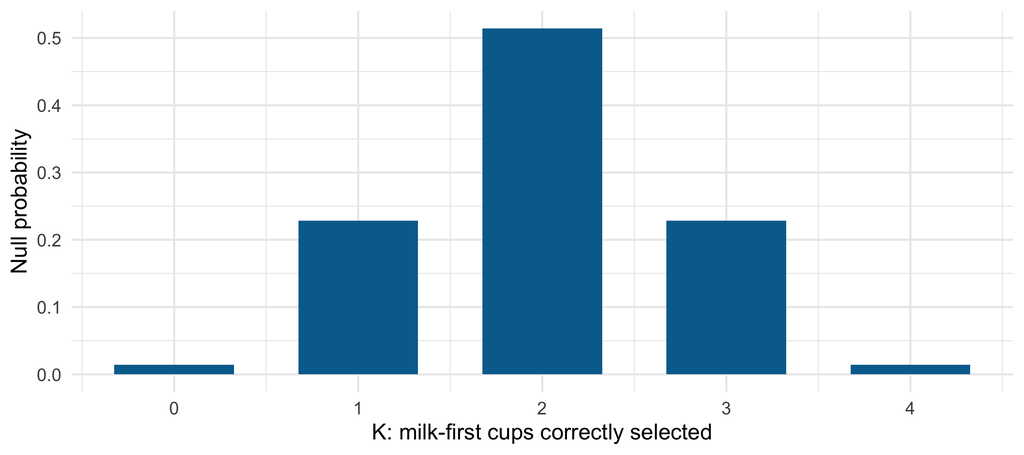

```r
p_tea_plot <- ggplot(tea, aes(k, prob)) +
  geom_col(fill = blue, width = .65) +
  scale_x_continuous(breaks = 0:4) +
  labs(x = "K: milk-first cups correctly selected", y = "Null probability")
p_tea_plot
```

# 2. One sample: statistic, p-value, and confidence interval

Suppose a political attitude score has population mean $\mu$. Test $H_0:\mu=50$ against $H_A:\mu\ne50$. The simulation below deliberately uses independent Normal observations, so the one-sample t reference is exact. In other settings, the studentized CLT can justify approximate inference.

```r
set.seed(21102)
score <- rnorm(50, mean = 54, sd = 12)
n <- length(score)
se <- sd(score) / sqrt(n)
t_obs <- (mean(score) - 50) / se
p_manual <- 2 * pt(-abs(t_obs), df = n - 1)
ci_manual <- mean(score) + c(-1, 1) * qt(.975, df = n - 1) * se
one_fit <- t.test(score, mu = 50)

c(mean = mean(score), SE = se, t = t_obs, p = p_manual)
```

```
        mean           SE            t            p
55.328342442  1.592156053  3.346620724  0.001577336
```

```r
ci_manual
```

```
[1] 52.12879 58.52790
```

```r
one_fit
```

```
    One Sample t-test

data:  score
t = 3.3466, df = 49, p-value = 0.001577
alternative hypothesis: true mean is not equal to 50
95 percent confidence interval:
 52.12879 58.52790
sample estimates:
mean of x
 55.32834
```

The two-sided p-value counts both tails beyond $\pm|t_{obs}|$. Does the 95% interval contain 50? Does the test reject at $\alpha=.05$? These decisions agree when we use the same SE, reference distribution, and confidence level. A one-sided alternative would need to be chosen **before** seeing the direction of the result; `alternative = "greater"` tests $\mu>50$.

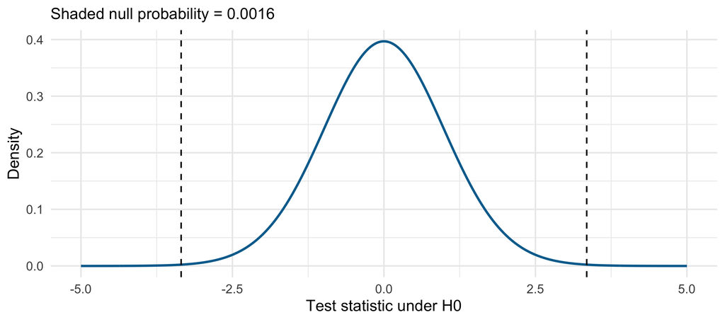

```r
ref <- data.frame(t = seq(-5, 5, length.out = 2001))
ref$density <- dt(ref$t, df = n - 1)
p_pvalue <- ggplot(ref, aes(t, density)) +
  geom_area(data = subset(ref, t <= -abs(t_obs)), fill = orange, alpha = .6) +
  geom_area(data = subset(ref, t >= abs(t_obs)), fill = orange, alpha = .6) +
  geom_line(color = blue, linewidth = 1) +
  geom_vline(xintercept = c(-abs(t_obs), abs(t_obs)), linetype = 2) +
  labs(x = "Test statistic under H0", y = "Density",
       subtitle = sprintf("Shaded null probability = %.4f", p_manual))
p_pvalue
```

# 3. Two independent samples: Welch’s test

Compare independent samples from two populations of attitude scores. Define the contrast as **Y minus X**. Unequal sample sizes and variances are allowed. These synthetic samples do not by themselves establish a causal effect.

```r
set.seed(21103)
x <- rnorm(30, mean = 50, sd = 10)
y <- rnorm(45, mean = 56, sd = 16)
d_hat <- mean(y) - mean(x)
se_diff <- sqrt(var(y) / length(y) + var(x) / length(x))
welch_fit <- t.test(y, x, mu = 0)

c(difference = d_hat, SE = se_diff, statistic = d_hat / se_diff)
```

```
difference         SE  statistic
  5.459330   3.202026   1.704961
```

```r
welch_fit
```

```
    Welch Two Sample t-test

data:  y and x
t = 1.705, df = 72.747, p-value = 0.09247
alternative hypothesis: true difference in means is not equal to 0
95 percent confidence interval:
 -0.9226738 11.8413330
sample estimates:
mean of x mean of y
 57.31333  51.85400
```

R’s default is Welch’s method (`var.equal = FALSE`). It uses a t reference with approximate degrees of freedom. It does **not** require equal population variances, but it still needs the observations and the groups to be independent for this SE formula. It does not solve dependence or confounding.

# 4. Paired observations: analyze the differences

The same 20 respondents answer before and after a debate. A respondent’s baseline attitude appears in both measurements. Responses within a person are related; the **people** are independent in this simulation.

```r
set.seed(21104)
before <- rnorm(20, mean = 50, sd = 12)
after <- before + rnorm(20, mean = 3, sd = 5)
change <- after - before
paired_fit <- t.test(after, before, paired = TRUE)
change_fit <- t.test(change, mu = 0)
paired_fit
```

```
    Paired t-test

data:  after and before
t = 1.7335, df = 19, p-value = 0.0992
alternative hypothesis: true mean difference is not equal to 0
95 percent confidence interval:
 -0.4675062  4.9759666
sample estimates:
mean difference
        2.25423
```

```r
change_fit
```

```
    One Sample t-test

data:  change
t = 1.7335, df = 19, p-value = 0.0992
alternative hypothesis: true mean is not equal to 0
95 percent confidence interval:
 -0.4675062  4.9759666
sample estimates:
mean of x
  2.25423
```

```r
c(paired_SE = sd(change) / sqrt(length(change)),
  ignoring_pairs_SE = sqrt(var(after) / length(after) +
                             var(before) / length(before)))
```

```
        paired_SE ignoring_pairs_SE
         1.300385          3.786465
```

Here pairing reduces the SE because the before/after covariance is positive. That is a property of these data, not a guarantee for every pair of variables. A before/after comparison alone does not isolate the debate’s causal effect.

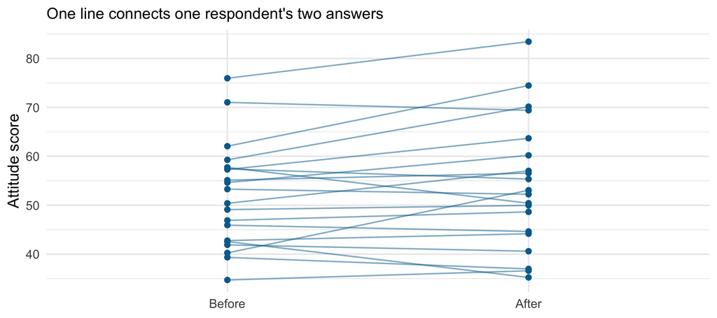

```r
paired_data <- data.frame(id = rep(1:20, 2),
                          time = factor(rep(c("Before", "After"), each = 20),
                                        levels = c("Before", "After")),
                          score = c(before, after))
p_pairs <- ggplot(paired_data, aes(time, score, group = id)) +
  geom_line(color = blue, alpha = .5) + geom_point(color = blue) +
  labs(x = NULL, y = "Attitude score", subtitle = "One line connects one respondent's two answers")
p_pairs
```

# 5. Power: repeat an entire study

Imagine two independent groups of attitude scores with a common population SD of 10. Let $\delta=\mu_Y-\mu_X$ be the true difference and let `n_group` be the sample size **in each group**. We simulate the same Welch test we would use to analyze a study. Record whether each fresh study rejects $H_0:\delta=0$.

```r
reject_once <- function(n_group, delta, sigma = 10, alpha = .05) {
  x_new <- rnorm(n_group, mean = 50, sd = sigma)
  y_new <- rnorm(n_group, mean = 50 + delta, sd = sigma)
  t.test(y_new, x_new)$p.value < alpha
}

set.seed(21105)
power_grid <- expand.grid(n_group = c(30, 60, 120), delta = c(0, 3, 6))
power_grid$rejection_rate <- vapply(seq_len(nrow(power_grid)), function(i) {
  mean(replicate(B, reject_once(power_grid$n_group[i], power_grid$delta[i])))
}, numeric(1))
power_grid$MCSE <- sqrt(power_grid$rejection_rate *
                         (1 - power_grid$rejection_rate) / B)
power_grid
```

```
  n_group delta rejection_rate        MCSE
1      30     0        0.05475 0.003596958
2      60     0        0.04775 0.003371570
3     120     0        0.05275 0.003534382
4      30     3        0.20800 0.006417476
5      60     3        0.37700 0.007662751
6     120     3        0.65500 0.007516232
7      30     6        0.62825 0.007641203
8      60     6        0.90925 0.004541873
9     120     6        0.99600 0.000997998
```

At $\delta=0$, the rejection rate estimates the Type I error rate. At a specified nonzero $\delta$, it estimates power. More simulated repetitions reduce **Monte Carlo error**; more subjects per group change the study’s power.

## A Normal approximation for the graph

For these planning assumptions, the population SE of the difference is $s=10\sqrt{2/n}$. Approximate its sampling distribution by $N(\delta,s^2)$ and reject when $|\widehat D|>1.96s$. The rejection cutoffs come from the null; we evaluate their probability under each alternative.

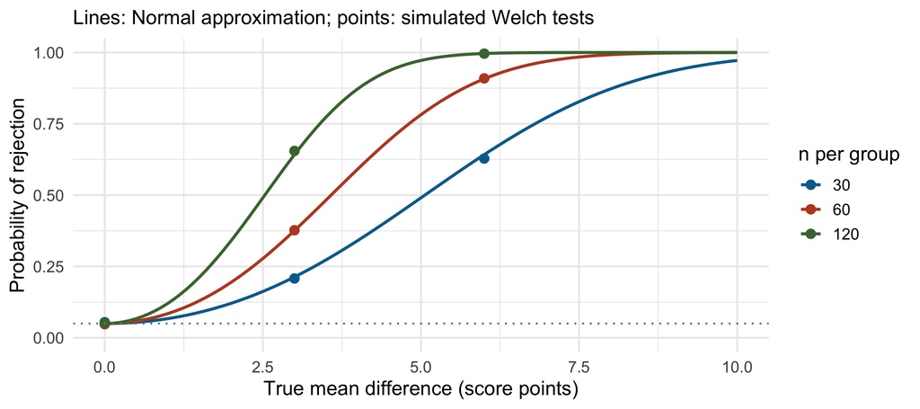

```r
normal_power <- function(delta, n_group, sigma = 10, alpha = .05) {
  s <- sigma * sqrt(2 / n_group)
  cutoff <- qnorm(1 - alpha / 2) * s
  pnorm(-cutoff, mean = delta, sd = s) +
    pnorm(cutoff, mean = delta, sd = s, lower.tail = FALSE)
}

power_curves <- expand.grid(delta = seq(0, 10, by = .1),
                           n_group = c(30, 60, 120))
power_curves$power <- with(power_curves, normal_power(delta, n_group))
p_power_curves <- ggplot(power_curves,
                        aes(delta, power, color = factor(n_group))) +
  geom_line(linewidth = 1) +
  geom_point(data = power_grid, aes(y = rejection_rate), size = 2.6) +
  geom_hline(yintercept = .05, linetype = 3, color = "gray50") +
  scale_color_manual(values = c(blue, orange, "#47733D"), name = "n per group") +
  coord_cartesian(ylim = c(0, 1)) +
  labs(x = "True mean difference (score points)", y = "Probability of rejection",
       subtitle = "Lines: Normal approximation; points: simulated Welch tests")
p_power_curves
```

The small gaps also reflect that Welch’s test estimates the SE and uses a t cutoff; the curves use the population SE and a Normal cutoff.

## Planning a sample size in R

`power.t.test()` provides a convenient calculation for a balanced, common-SD Normal model using the pooled two-sample t test. This is a planning model; it is not an exact power calculation for every design or for unequal-variance Welch tests. Simulation lets us explore the procedure and design we actually intend.

```r
plan <- power.t.test(delta = 3, sd = 10, power = .80,
                     sig.level = .05, type = "two.sample",
                     alternative = "two.sided", strict = TRUE)
plan
```

```
     Two-sample t test power calculation

              n = 175.3847
          delta = 3
             sd = 10
      sig.level = 0.05
          power = 0.8
    alternative = two.sided

NOTE: n is number in *each* group
```

```r
ceiling(plan$n)  # Round up: number needed IN EACH GROUP.
```

```
[1] 176
```

`strict = TRUE` counts rejections in either tail, as a two-sided test does. Plan around a substantively meaningful effect and plausible variability, not the observed effect from the study whose p-value you are interpreting.

# 6. Bootstrap: approximate sampling uncertainty

Reuse the 50 attitude scores from Section 2. Treat their empirical distribution (each observed score gets probability $1/n$) as a stand-in for the unknown population. Draw samples of size $n$ **with replacement**, recomputing the mean.

```r
set.seed(21106)
boot_mean <- replicate(B, {
  score_star <- sample(score, size = length(score), replace = TRUE)
  mean(score_star)
})
c(estimate = mean(score), bootstrap_SE = sd(boot_mean),
  formula_SE = sd(score) / sqrt(length(score)))
```

```
    estimate bootstrap_SE   formula_SE
   55.328342     1.572125     1.592156
```

```r
quantile(boot_mean, c(.025, .975))  # Approximate percentile interval.
```

```
    2.5%    97.5%
52.11188 58.43028
```

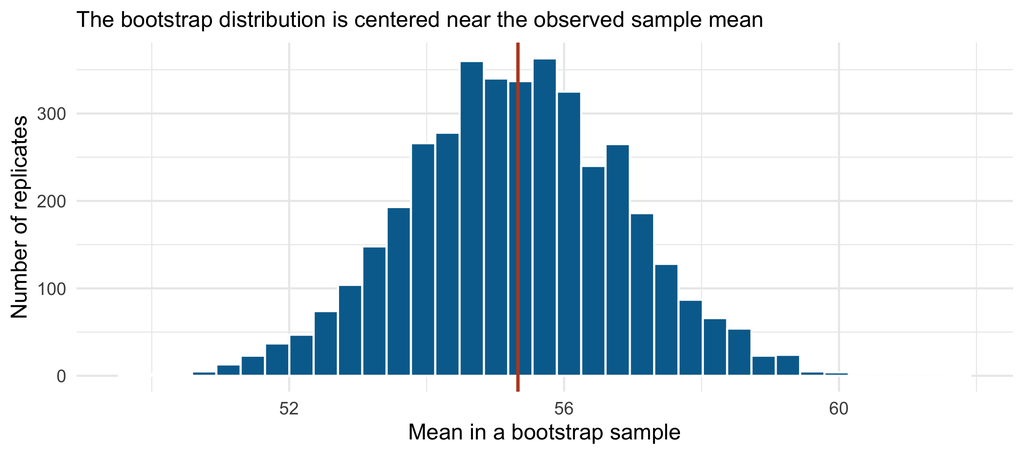

```r
p_boot_mean <- ggplot(data.frame(estimate = boot_mean), aes(estimate)) +
  geom_histogram(bins = 35, fill = blue, color = "white") +
  geom_vline(xintercept = mean(score), color = orange, linewidth = 1) +
  labs(x = "Mean in a bootstrap sample", y = "Number of replicates",
       subtitle = "The bootstrap distribution is centered near the observed sample mean")
p_boot_mean
```

The bootstrap SD estimates the estimator’s standard error. The percentile interval is an approximate method, not an exact coverage guarantee. These replicates fluctuate around the observed mean, **not around the null mean 50**. Counting how often `boot_mean` exceeds the observed mean would not give a valid p-value for $H_0:\mu=50$.

This is the idea behind the bootstrap summaries provided in B4. It can also help with statistics whose SE formulas are less familiar, such as a median or ratio. Its validity still depends on the sampling structure and statistic.

# 7. Dependence: keep households together

Gerber, Green, and Larimer assigned treatment at the household level, within geographic blocks. Our **synthetic illustration** uses a simpler design: 60 independent households, two voters each, and exactly 30 treated households. Potential outcomes are fixed once generated; assignment determines which we see.

The latent household propensity creates related outcomes within a household. The optional details of generating potential outcomes are shown here so the example is completely reproducible; the resampling starts with `voters`.

```r
set.seed(21107)
H <- 60
household_propensity <- rbeta(H, shape1 = .3, shape2 = .7)
household <- rep(seq_len(H), each = 2)
u <- runif(2 * H)
p0 <- household_propensity[household]
p1 <- plogis(qlogis(p0) + .6)
y0 <- as.integer(u < p0)
y1 <- as.integer(u < p1)
assigned <- sample(rep(c(0, 1), each = H / 2))
voters <- data.frame(household, treated = assigned[household],
                     voted = ifelse(assigned[household] == 1, y1, y0))

hh <- voters |>
  group_by(household, treated) |>
  summarise(turnout = mean(voted), .groups = "drop")
head(voters)
```

```
  household treated voted
1         1       1     1
2         1       1     1
3         2       0     0
4         2       0     0
5         3       1     1
6         3       1     1
```

```r
head(hh)
```

```
# A tibble: 6 × 3
  household treated turnout
      <int>   <dbl>   <dbl>
1         1       1     1
2         2       0     0
3         3       1     1
4         4       1     0.5
5         5       0     1
6         6       1     0
```

Each household mean is 0, 0.5, or 1. Because every household has two voters, the mean of household means equals the mean across voters in that arm. With unequal household sizes, averaging household rates and averaging voters can target different quantities; preserve the intended weighting.

```r
h_treated <- hh$turnout[hh$treated == 1]
h_control <- hh$turnout[hh$treated == 0]
observed <- mean(h_treated) - mean(h_control)

set.seed(21108)
boot_household <- replicate(B, {
  t_star <- sample(h_treated, length(h_treated), replace = TRUE)
  c_star <- sample(h_control, length(h_control), replace = TRUE)
  mean(t_star) - mean(c_star)
})
observed
```

```
[1] 0.1833333
```

```r
sd(boot_household)
```

```
[1] 0.09958091
```

We resample household summaries **within each arm**, with replacement. For this equal-size, mean-outcome example, that preserves exactly the contribution of resampling whole households with all their voters. This bootstrap models sampling independent households; it is not the experiment’s reassignment test.

## Compare with resampling individual voters

```r
v_treated <- voters$voted[voters$treated == 1]
v_control <- voters$voted[voters$treated == 0]
set.seed(21109)
boot_voter <- replicate(B, {
  mean(sample(v_treated, length(v_treated), replace = TRUE)) -
    mean(sample(v_control, length(v_control), replace = TRUE))
})
bootstrap_comparison <- data.frame(
  resampling_unit = c("Individual voter", "Whole household"),
  bootstrap_SE = c(sd(boot_voter), sd(boot_household)))
bootstrap_comparison
```

```
   resampling_unit bootstrap_SE
1 Individual voter   0.08155770
2  Whole household   0.09958091
```

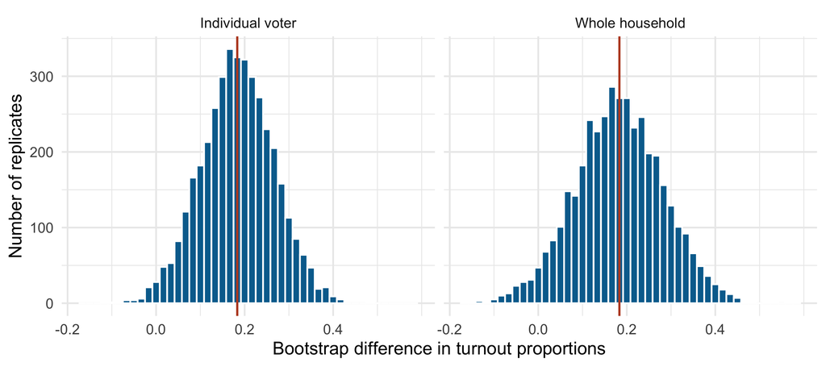

```r
boot_comparison <- data.frame(
  estimate = c(boot_voter, boot_household),
  unit = rep(c("Individual voter", "Whole household"), each = B))
p_cluster_boot <- ggplot(boot_comparison, aes(estimate)) +
  geom_histogram(binwidth = 1 / 60, fill = blue, color = "white") +
  geom_vline(xintercept = observed, color = orange, linewidth = .8) +
  facet_wrap(~unit, nrow = 1) +
  scale_x_continuous(breaks = c(-.2, 0, .2, .4)) +
  labs(x = "Bootstrap difference in turnout proportions", y = "Number of replicates")
p_cluster_boot
```

The row bootstrap breaks the positive within-household association and understates uncertainty here. This is the same dependence issue as repeated responses in A6. More rows need not mean more independent information.

# 8. A null distribution from randomized assignments

For the synthetic experiment, consider the **sharp null**: treatment changes no voter’s outcome, $Y_i(1)=Y_i(0)$ for every voter. Under that null, the observed outcomes would be the same under every allowed assignment. Keep them fixed; randomly assign exactly 30 of the 60 **households** to treatment again.

```r
set.seed(21110)
null_difference <- replicate(B, {
  d_star <- sample(hh$treated, replace = FALSE)
  mean(hh$turnout[d_star == 1]) - mean(hh$turnout[d_star == 0])
})
# Count ties as at least as extreme; tolerance handles floating-point rounding.
extreme <- abs(null_difference) >= abs(observed) - 1e-12
p_randomization <- (1 + sum(extreme)) / (B + 1)
c(observed_difference = observed, randomization_p = p_randomization)
```

```
observed_difference     randomization_p
          0.1833333           0.1102224
```

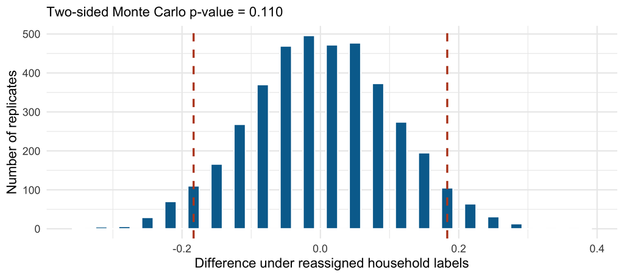

```r
p_randomization_plot <- ggplot(data.frame(difference = null_difference),
                              aes(difference)) +
  geom_histogram(binwidth = 1 / 60, fill = blue, color = "white") +
  geom_vline(xintercept = c(-abs(observed), abs(observed)),
             color = orange, linewidth = 1, linetype = 2) +
  labs(x = "Difference under reassigned household labels", y = "Number of replicates",
       subtitle = sprintf("Two-sided Monte Carlo p-value = %.3f", p_randomization))
p_randomization_plot
```

Unlike the bootstrap, these labels are shuffled **without replacement**: every household appears once and the treatment count is unchanged. The `+1` correction includes the observed assignment in the Monte Carlo calculation and avoids a reported p-value of zero. Full enumeration would use its exact tail proportion instead.

A sharp null is stronger than a zero **average** effect: positive and negative individual effects could cancel. This simple randomization test is justified by the sharp null and the assignment design (also assuming no interference between households). It is not a generic exact test of equal means for arbitrary observational groups.

**For the actual Gerber–Green–Larimer design**, reassign households within the original blocks and retain each block’s treatment-arm counts. Do not apply our unrestricted two-arm shuffle to their data.

# 9. Choose the repetition to match the question

| Goal | What gets repeated? | What remains fixed? |
| --- | --- | --- |
| Power | Generate fresh studies under a specified true effect | Design, analysis rule, and model parameters |
| Bootstrap SE | Sample units with replacement from observed data | Sample size and the chosen resampling structure |
| Randomization test | Draw assignments allowed by the design | Outcomes under the sharp null, units, and design constraints |

For paired data, resample pairs. For households or schools, preserve clusters. For serial dependence, a suitable block or time-series method is needed. Resampling is not a repair for a biased sample, confounding, or too few independent units.

# Reading and references

- *Probability, Statistics, and Data*, [Chapter 8](https://probstatsdata.com/HTCI.html), especially §§8.3–8.4 and 8.6–8.8.
- Matthew Blackwell, *Gov 2000: Hypothesis Testing* (2016), used with permission; motivating tea example and testing/power sequence.
- Gerber, A. S., Green, D. P., and Larimer, C. W. (2008). “Social Pressure and Voter Turnout: Evidence from a Large-Scale Field Experiment.” *American Political Science Review* 102(1):33–48. [Article](https://doi.org/10.1017/S000305540808009X).
- R documentation: [`t.test`](https://stat.ethz.ch/R-manual/R-devel/library/stats/html/t.test.html), [`power.t.test`](https://stat.ethz.ch/R-manual/R-devel/library/stats/html/power.t.test.html).